# Diabetes Patients

## About Dataset

#### This dataset is originally from the National Institute of Diabetes and Digestive and Kidney Diseases.

## Objective

#### This dataset is originally from the National Institute of Diabetes and Digestive and KidneyDiseases. The objective of the dataset is to diagnostically predict whether a patient has diabetes based on certain diagnostic measurements included in the dataset.

## Content:

##### 1. Loading the dataset

##### 2. Data cleaning

##### 3. Data visualization

##### 4.Data Modelling

### Import the libraries:

```python
import numpy as np      #for mathemtical operation
import pandas as pd     # for reading and analyze data
import seaborn as sns
import matplotlib.pyplot as plt    # for visualizing data
import warnings
warnings.filterwarnings("ignore")
```

### Loading the dataset

```python
# Loading and reading the dataset
df = pd.read_csv(r"C:\Users\ABC\Downloads\diabetes.csv")
```

```python
df.shape
```

```
(768, 9)
```

```python
df.head()
```

|  | Pregnancies | Glucose | BloodPressure | SkinThickness | Insulin | BMI | DiabetesPedigreeFunction | Age | Outcome |
| --- | --- | --- | --- | --- | --- | --- | --- | --- | --- |
| 0 | 6 | 148 | 72 | 35 | 0 | 33.6 | 0.627 | 50 | 1 |
| 1 | 1 | 85 | 66 | 29 | 0 | 26.6 | 0.351 | 31 | 0 |
| 2 | 8 | 183 | 64 | 0 | 0 | 23.3 | 0.672 | 32 | 1 |
| 3 | 1 | 89 | 66 | 23 | 94 | 28.1 | 0.167 | 21 | 0 |
| 4 | 0 | 137 | 40 | 35 | 168 | 43.1 | 2.288 | 33 | 1 |

```python
df.info()
```

```
<class 'pandas.core.frame.DataFrame'>
RangeIndex: 768 entries, 0 to 767
Data columns (total 9 columns):
 #   Column                    Non-Null Count  Dtype
---  ------                    --------------  -----
 0   Pregnancies               768 non-null    int64
 1   Glucose                   768 non-null    int64
 2   BloodPressure             768 non-null    int64
 3   SkinThickness             768 non-null    int64
 4   Insulin                   768 non-null    int64
 5   BMI                       768 non-null    float64
 6   DiabetesPedigreeFunction  768 non-null    float64
 7   Age                       768 non-null    int64
 8   Outcome                   768 non-null    int64
dtypes: float64(2), int64(7)
memory usage: 54.1 KB
```

```python
# To check  null values
pd.isnull(df).sum()
```

```
Pregnancies                 0
Glucose                     0
BloodPressure               0
SkinThickness               0
Insulin                     0
BMI                         0
DiabetesPedigreeFunction    0
Age                         0
Outcome                     0
dtype: int64
```

#### We can see that no null values in dataset.

```python
# to check columns
df.columns
```

```
Index(['Pregnancies', 'Glucose', 'BloodPressure', 'SkinThickness', 'Insulin',
       'BMI', 'DiabetesPedigreeFunction', 'Age', 'Outcome'],
      dtype='object')
```

```python
# describe()  method returns description of the data in the dataframe(i.e, count,mean,std,etc)
df.describe()
```

|  | Pregnancies | Glucose | BloodPressure | SkinThickness | Insulin | BMI | DiabetesPedigreeFunction | Age | Outcome |
| --- | --- | --- | --- | --- | --- | --- | --- | --- | --- |
| count | 768.000000 | 768.000000 | 768.000000 | 768.000000 | 768.000000 | 768.000000 | 768.000000 | 768.000000 | 768.000000 |
| mean | 3.845052 | 120.894531 | 69.105469 | 20.536458 | 79.799479 | 31.992578 | 0.471876 | 33.240885 | 0.348958 |
| std | 3.369578 | 31.972618 | 19.355807 | 15.952218 | 115.244002 | 7.884160 | 0.331329 | 11.760232 | 0.476951 |
| min | 0.000000 | 0.000000 | 0.000000 | 0.000000 | 0.000000 | 0.000000 | 0.078000 | 21.000000 | 0.000000 |
| 25% | 1.000000 | 99.000000 | 62.000000 | 0.000000 | 0.000000 | 27.300000 | 0.243750 | 24.000000 | 0.000000 |
| 50% | 3.000000 | 117.000000 | 72.000000 | 23.000000 | 30.500000 | 32.000000 | 0.372500 | 29.000000 | 0.000000 |
| 75% | 6.000000 | 140.250000 | 80.000000 | 32.000000 | 127.250000 | 36.600000 | 0.626250 | 41.000000 | 1.000000 |
| max | 17.000000 | 199.000000 | 122.000000 | 99.000000 | 846.000000 | 67.100000 | 2.420000 | 81.000000 | 1.000000 |

```python
df.duplicated().sum()
```

```
0
```

### Data Visualization

```python
df.Pregnancies.unique()
```

```
array([ 6,  1,  8,  0,  5,  3, 10,  2,  4,  7,  9, 11, 13, 15, 17, 12, 14],
      dtype=int64)
```

```python
pd.DataFrame(df[["Pregnancies"]].value_counts()).sort_values(by="Pregnancies")
```

| Pregnancies | 0 |
| --- | --- |
| 0 | 111 |
| 1 | 135 |
| 2 | 103 |
| 3 | 75 |
| 4 | 68 |
| 5 | 57 |
| 6 | 50 |
| 7 | 45 |
| 8 | 38 |
| 9 | 28 |
| 10 | 24 |
| 11 | 11 |
| 12 | 9 |
| 13 | 10 |
| 14 | 2 |
| 15 | 1 |
| 17 | 1 |

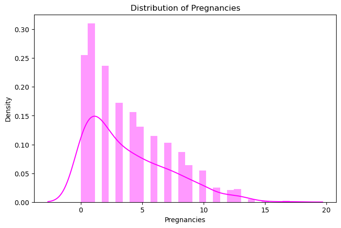

```python
plt.figure(figsize=(8,5))
sns.distplot(df["Pregnancies"],bins = 30,color = "magenta")
plt.title("Distribution of Pregnancies")
```

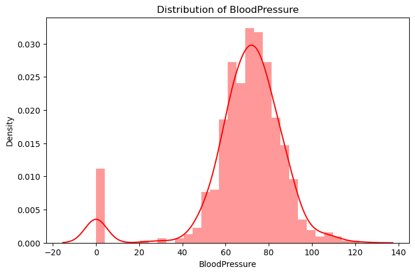

```python
plt.figure(figsize=(8,5))
sns.distplot(df["BloodPressure"],bins = 30,color = "Red")
plt.title("Distribution of BloodPressure")
```

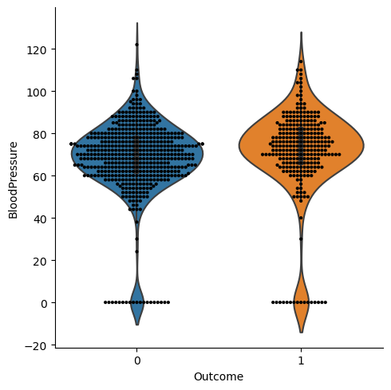

```python
plt.figure(figsize=(6,5))
g = sns.catplot(data = df, x="Outcome", y= "BloodPressure", kind="violin",innerplace=True)
sns.swarmplot(data = df,x = "Outcome", y= "BloodPressure",color= "k",size=3)
```

##### 0blood pressure is not accountable data sowe are replacing 0 with mean value.

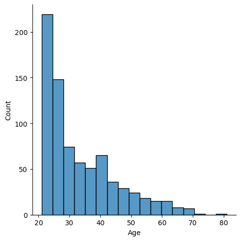

```python
sns.displot(df,x= "Age")
```

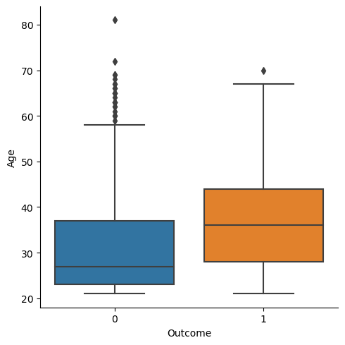

```python
plt.figure(figsize=(6,5))
sns.catplot(data=df, x="Outcome", y="Age",kind="box")
```

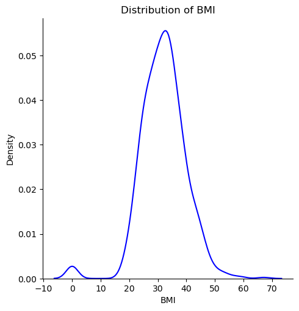

```python
plt.figure(figsize=(6,5))
sns.displot(df,x="BMI",color="blue",kind="kde")
plt.title("Distribution of BMI")
```

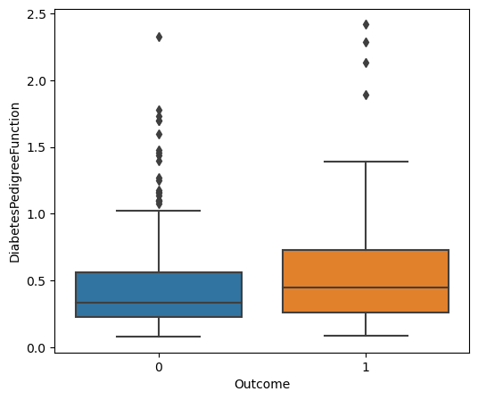

```python
plt.figure(figsize=(6,5))
sns.boxplot(x="Outcome", y="DiabetesPedigreeFunction",data=df)
```

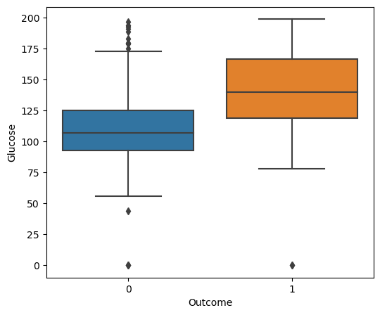

```python
plt.figure(figsize=(6,5))
sns.boxplot(x="Outcome", y="Glucose",data=df)
```

```python
df['Outcome'].value_counts()
```

```
0    500
1    268
Name: Outcome, dtype: int64
```

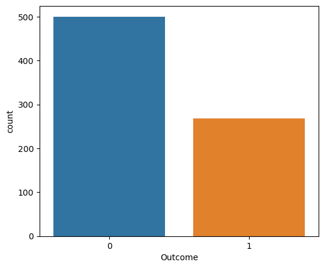

```python
plt.figure(figsize=(6,5))
sns.countplot(df['Outcome'])
```

### Data processing

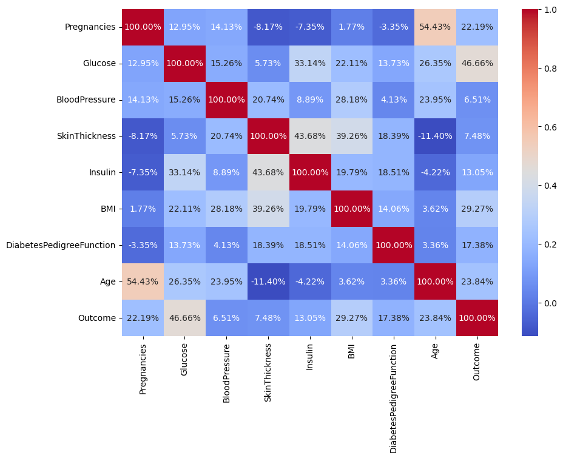

```python
plt.figure(figsize=(10,7))
sns.heatmap(df.corr(),annot=True,fmt=".2%",cmap="coolwarm")
```

#### Outlier Removal

```python
avg = df["BloodPressure"].mean()
df["BloodPressure"] = df["BloodPressure"].apply(lambda v:avg if v==0 else v)
```

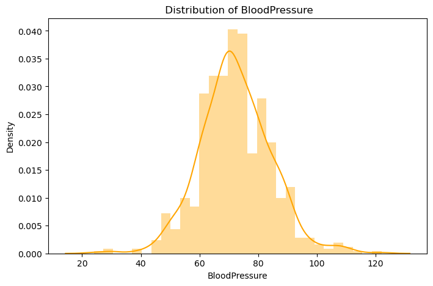

```python
plt.figure(figsize = (8,5))
sns.distplot(df["BloodPressure"] , bins = 30,color = "Orange")
plt.title(" Distribution of BloodPressure")
```

```python
bmi_avg = df["BMI"].mean()
df["BMI"] = df["BMI"].apply(lambda v:avg if v==0 else v)
```

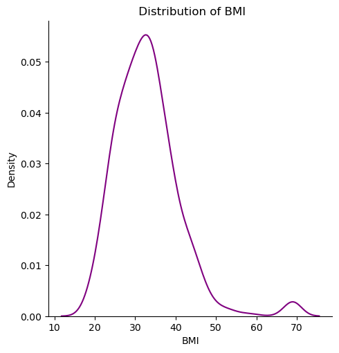

```python
plt.figure(figsize = (8,5))
sns.displot(df, x="BMI",color = "Purple",kind= "kde")
plt.title(" Distribution of BMI")
```

- As seen earlier there are amount whivh varies largely from rest of amount .It may not me outlier in real case bot for better modelling we need to remove it.
- In above varible i replaced outlier value with mean. Noe lets use z-score technique to see outlier in other feature variable.

```python
df["z_score_bp"]=(df.BloodPressure-df.BloodPressure.mean()/df.BloodPressure.std())
df["z_score_Glucose"]=(df.Glucose-df.Glucose.mean()/df.Glucose.std())
```

```python
df.head()
```

|  | Pregnancies | Glucose | BloodPressure | SkinThickness | Insulin | BMI | DiabetesPedigreeFunction | Age | Outcome | z_score_bp | z_score_Glucose |
| --- | --- | --- | --- | --- | --- | --- | --- | --- | --- | --- | --- |
| 0 | 6 | 148 | 72.0 | 35 | 0 | 33.6 | 0.627 | 50 | 1 | 66.03638 | 144.21881 |
| 1 | 1 | 85 | 66.0 | 29 | 0 | 26.6 | 0.351 | 31 | 0 | 60.03638 | 81.21881 |
| 2 | 8 | 183 | 64.0 | 0 | 0 | 23.3 | 0.672 | 32 | 1 | 58.03638 | 179.21881 |
| 3 | 1 | 89 | 66.0 | 23 | 94 | 28.1 | 0.167 | 21 | 0 | 60.03638 | 85.21881 |
| 4 | 0 | 137 | 40.0 | 35 | 168 | 43.1 | 2.288 | 33 | 1 | 34.03638 | 133.21881 |

```python
df.describe()
```

|  | Pregnancies | Glucose | BloodPressure | SkinThickness | Insulin | BMI | DiabetesPedigreeFunction | Age | Outcome | z_score_bp | z_score_Glucose |
| --- | --- | --- | --- | --- | --- | --- | --- | --- | --- | --- | --- |
| count | 768.000000 | 768.000000 | 768.000000 | 768.000000 | 768.000000 | 768.000000 | 768.000000 | 768.000000 | 768.000000 | 768.000000 | 768.000000 |
| mean | 3.845052 | 120.894531 | 72.254807 | 20.536458 | 79.799479 | 32.982370 | 0.471876 | 33.240885 | 0.348958 | 66.291187 | 117.113342 |
| std | 3.369578 | 31.972618 | 12.115932 | 15.952218 | 115.244002 | 8.139636 | 0.331329 | 11.760232 | 0.476951 | 12.115932 | 31.972618 |
| min | 0.000000 | 0.000000 | 24.000000 | 0.000000 | 0.000000 | 18.200000 | 0.078000 | 21.000000 | 0.000000 | 18.036380 | -3.781190 |
| 25% | 1.000000 | 99.000000 | 64.000000 | 0.000000 | 0.000000 | 27.500000 | 0.243750 | 24.000000 | 0.000000 | 58.036380 | 95.218810 |
| 50% | 3.000000 | 117.000000 | 72.000000 | 23.000000 | 30.500000 | 32.400000 | 0.372500 | 29.000000 | 0.000000 | 66.036380 | 113.218810 |
| 75% | 6.000000 | 140.250000 | 80.000000 | 32.000000 | 127.250000 | 36.825000 | 0.626250 | 41.000000 | 1.000000 | 74.036380 | 136.468810 |
| max | 17.000000 | 199.000000 | 122.000000 | 99.000000 | 846.000000 | 69.105469 | 2.420000 | 81.000000 | 1.000000 | 116.036380 | 195.218810 |

```python
df.drop(columns=["z_score_bp",	"z_score_Glucose"],inplace=True)
df.head()
```

|  | Pregnancies | Glucose | BloodPressure | SkinThickness | Insulin | BMI | DiabetesPedigreeFunction | Age | Outcome |
| --- | --- | --- | --- | --- | --- | --- | --- | --- | --- |
| 0 | 6 | 148 | 72.0 | 35 | 0 | 33.6 | 0.627 | 50 | 1 |
| 1 | 1 | 85 | 66.0 | 29 | 0 | 26.6 | 0.351 | 31 | 0 |
| 2 | 8 | 183 | 64.0 | 0 | 0 | 23.3 | 0.672 | 32 | 1 |
| 3 | 1 | 89 | 66.0 | 23 | 94 | 28.1 | 0.167 | 21 | 0 |
| 4 | 0 | 137 | 40.0 | 35 | 168 | 43.1 | 2.288 | 33 | 1 |

### Split Data

```python
X= df.drop(columns="Outcome")
Y = df["Outcome"]
```

```python
X
```

|  | Pregnancies | Glucose | BloodPressure | SkinThickness | Insulin | BMI | DiabetesPedigreeFunction | Age |
| --- | --- | --- | --- | --- | --- | --- | --- | --- |
| 0 | 6 | 148 | 72.0 | 35 | 0 | 33.6 | 0.627 | 50 |
| 1 | 1 | 85 | 66.0 | 29 | 0 | 26.6 | 0.351 | 31 |
| 2 | 8 | 183 | 64.0 | 0 | 0 | 23.3 | 0.672 | 32 |
| 3 | 1 | 89 | 66.0 | 23 | 94 | 28.1 | 0.167 | 21 |
| 4 | 0 | 137 | 40.0 | 35 | 168 | 43.1 | 2.288 | 33 |
| ... | ... | ... | ... | ... | ... | ... | ... | ... |
| 763 | 10 | 101 | 76.0 | 48 | 180 | 32.9 | 0.171 | 63 |
| 764 | 2 | 122 | 70.0 | 27 | 0 | 36.8 | 0.340 | 27 |
| 765 | 5 | 121 | 72.0 | 23 | 112 | 26.2 | 0.245 | 30 |
| 766 | 1 | 126 | 60.0 | 0 | 0 | 30.1 | 0.349 | 47 |
| 767 | 1 | 93 | 70.0 | 31 | 0 | 30.4 | 0.315 | 23 |

768 rows × 8 columns

```python
Y.head()
```

```
0    1
1    0
2    1
3    0
4    1
Name: Outcome, dtype: int64
```

```python
X.shape, Y.shape
```

```
((768, 8), (768,))
```

```python
from sklearn.model_selection import train_test_split
x_train,x_test,y_train,y_test = train_test_split(X,Y,test_size=0.25,random_state=30)
```

```python
x_train.shape , x_test.shape
```

```
((576, 8), (192, 8))
```

```python
y_train.shape , y_test.shape
```

```
((576,), (192,))
```

## Model building

### Logistic Regression

```python
from sklearn.linear_model import LogisticRegression
M_l = LogisticRegression()
```

```python
M_l.fit(x_train , y_train)
```

```
LogisticRegression()
```

```python
y_predicted_l = M_l.predict(x_test)
```

```python
M_l.score(x_test , y_test)
```

```
0.8020833333333334
```

###### Evaluate the model performance using matrics like Accuracy,Confusion Matrix and Classification Report

```python
from sklearn.metrics import accuracy_score,confusion_matrix,classification_report
```

```python
Accuracy = accuracy_score(y_test,y_predicted_l)
print('Accuracy:',Accuracy)
```

```
Accuracy: 0.8020833333333334
```

```python
Confusion_matrix = confusion_matrix(y_test,y_predicted_l)
print('Confusion_matrix: \n',Confusion_matrix)
```

```
Confusion_matrix:
 [[117  13]
 [ 25  37]]
```

```python
Classification_report = classification_report(y_test,y_predicted_l)
print('Classification_report: \n',Classification_report)
```

```
Classification_report:
               precision    recall  f1-score   support

           0       0.82      0.90      0.86       130
           1       0.74      0.60      0.66        62

    accuracy                           0.80       192
   macro avg       0.78      0.75      0.76       192
weighted avg       0.80      0.80      0.80       192
```

```python
from sklearn.metrics import recall_score,precision_score,f1_score

Recall = recall_score(y_test,y_predicted_l)
print('Recall:',Recall)

Precision = precision_score(y_test,y_predicted_l)
print('Precision:',Precision)

F1_score = f1_score(y_test,y_predicted_l)
print('F1_score:',F1_score)
```

```
Recall: 0.5967741935483871
Precision: 0.74
F1_score: 0.6607142857142857
```

### Decision Tree Classifier

```python
from sklearn.tree import DecisionTreeClassifier
M_d =  DecisionTreeClassifier()
```

```python
M_d.fit(x_train , y_train)
```

```
DecisionTreeClassifier()
```

```python
y_predicted_d = M_d.predict(x_test)
```

```python
M_d.score(x_test , y_test)
```

```
0.6927083333333334
```

###### Evaluate the model performance using matrics like Accuracy,Confusion Matrix and Classification Report

```python
Accuracy = accuracy_score(y_test,y_predicted_d)
print('Accuracy:',Accuracy)
```

```
Accuracy: 0.6927083333333334
```

```python
Confusion_matrix = confusion_matrix(y_test,y_predicted_d)
print('Confusion_matrix: \n',Confusion_matrix)
```

```
Confusion_matrix:
 [[98 32]
 [27 35]]
```

```python
Classification_report = classification_report(y_test,y_predicted_d)
print('Classification_report: \n',Classification_report)
```

```
Classification_report:
               precision    recall  f1-score   support

           0       0.78      0.75      0.77       130
           1       0.52      0.56      0.54        62

    accuracy                           0.69       192
   macro avg       0.65      0.66      0.66       192
weighted avg       0.70      0.69      0.70       192
```

```python
Recall = recall_score(y_test,y_predicted_d)
print('Recall:',Recall)

Precision = precision_score(y_test,y_predicted_d)
print('Precision:',Precision)

F1_score = f1_score(y_test,y_predicted_d)
print('F1_score:',F1_score)
```

```
Recall: 0.5645161290322581
Precision: 0.5223880597014925
F1_score: 0.5426356589147286
```

### Decision Tree Classifier with criterion gini index

```python
# instantiate the DecisionTreeClassifier model with criterion gini index
clf_gini = DecisionTreeClassifier(criterion='gini', max_depth=3, random_state=0)


# fit the model
clf_gini.fit(x_train, y_train)
```

```
DecisionTreeClassifier(max_depth=3, random_state=0)
```

```python
y_predict_gini = clf_gini.predict(x_test)
```

#### Check accuracy score with criterion gini index

```python
from sklearn.metrics import accuracy_score

print('Model accuracy score with criterion gini index: {0:0.4f}'. format(accuracy_score(y_test, y_predict_gini)))
```

```
Model accuracy score with criterion gini index: 0.7969
```

- Here, y_test are the true class labels and y_pred_gini are the predicted class labels in the test-set.

Compare the train-set and test-set accuracy Now, I will compare the train-set and test-set accuracy to check for overfitting.

```python
y_pred_train_gini = clf_gini.predict(x_train)

y_pred_train_gini
```

[output not shown]

```python
print('Training-set accuracy score: {0:0.4f}'. format(accuracy_score(y_train, y_pred_train_gini)))
```

```
Training-set accuracy score: 0.7708
```

#### Check for overfitting and underfitting

```python
print('Training set score: {:.4f}'.format(clf_gini.score(x_train, y_train)))

print('Test set score: {:.4f}'.format(clf_gini.score(x_test, y_test)))
```

```
Training set score: 0.7708
Test set score: 0.7969
```

#### Here, the training-set accuracy score is 0.7708 while the test-set accuracy to be 0.7969. These two values are quite comparable. So, there is no sign of overfitting.

Visualize decision-trees

[output not shown]

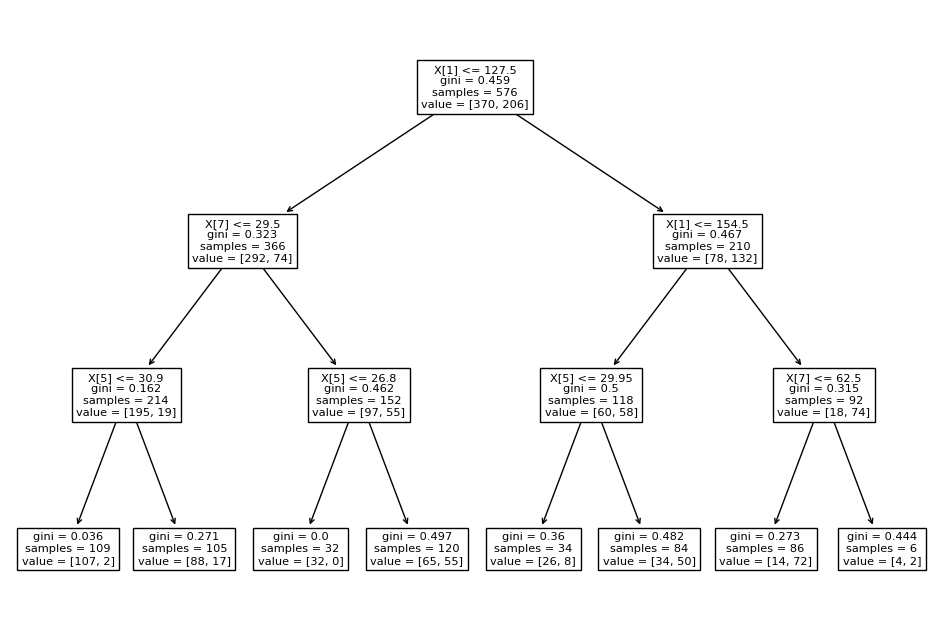

```python
plt.figure(figsize=(12,8))

from sklearn import tree

tree.plot_tree(clf_gini.fit(x_train, y_train))
```

### Random Forest Classifier

```python
from sklearn.ensemble import RandomForestClassifier
M_rf =  RandomForestClassifier(n_estimators=10)
```

```python
M_rf.fit(x_train , y_train)
```

```
RandomForestClassifier(n_estimators=10)
```

```python
y_predicted_rf = M_rf.predict(x_test)
```

```python
M_rf.score(x_test , y_test)
```

```
0.7708333333333334
```

###### Evaluate the model performance using matrics like Accuracy,Confusion Matrix and Classification Report

```python
Accuracy = accuracy_score(y_test,y_predicted_rf)
print('Accuracy:',Accuracy)
```

```
Accuracy: 0.7708333333333334
```

```python
Confusion_matrix = confusion_matrix(y_test,y_predicted_rf)
print('Confusion_matrix: \n',Confusion_matrix)
```

```
Confusion_matrix:
 [[112  18]
 [ 26  36]]
```

```python
Classification_report = classification_report(y_test,y_predicted_rf)
print('Classification_report: \n',Classification_report)
```

```
Classification_report:
               precision    recall  f1-score   support

           0       0.81      0.86      0.84       130
           1       0.67      0.58      0.62        62

    accuracy                           0.77       192
   macro avg       0.74      0.72      0.73       192
weighted avg       0.76      0.77      0.77       192
```

```python
Recall = recall_score(y_test,y_predicted_rf)
print('Recall:',Recall)

Precision = precision_score(y_test,y_predicted_rf)
print('Precision:',Precision)

F1_score = f1_score(y_test,y_predicted_rf)
print('F1_score:',F1_score)
```

```
Recall: 0.5806451612903226
Precision: 0.6666666666666666
F1_score: 0.6206896551724138
```

### Gaussian Naive Bayes Classifier

```python
from sklearn.naive_bayes import GaussianNB
M_NB = GaussianNB()
```

```python
M_NB.fit(x_train , y_train)
```

```
GaussianNB()
```

```python
y_predicted_NB = M_rf.predict(x_test)
```

```python
M_NB.score(x_test , y_test)
```

```
0.7760416666666666
```

###### Evaluate the model performance using matrics like Accuracy,Confusion Matrix and Classification Report

```python
Accuracy = accuracy_score(y_test,y_predicted_NB)
print('Accuracy:',Accuracy)
```

```
Accuracy: 0.7708333333333334
```

```python
Confusion_matrix = confusion_matrix(y_test,y_predicted_NB)
print('Confusion_matrix: \n',Confusion_matrix)
```

```
Confusion_matrix:
 [[112  18]
 [ 26  36]]
```

```python
Classification_report = classification_report(y_test,y_predicted_NB)
print('Classification_report: \n',Classification_report)
```

```
Classification_report:
               precision    recall  f1-score   support

           0       0.81      0.86      0.84       130
           1       0.67      0.58      0.62        62

    accuracy                           0.77       192
   macro avg       0.74      0.72      0.73       192
weighted avg       0.76      0.77      0.77       192
```

```python
Recall = recall_score(y_test,y_predicted_NB)
print('Recall:',Recall)

Precision = precision_score(y_test,y_predicted_NB)
print('Precision:',Precision)

F1_score = f1_score(y_test,y_predicted_NB)
print('F1_score:',F1_score)
```

```
Recall: 0.5806451612903226
Precision: 0.6666666666666666
F1_score: 0.6206896551724138
```

#### Result : The most of accuracy is given by logistic regression Classifer Model.It gives 80.20% accuracy.